# DZ1

# Теперь к вопросу о взаимодействии факторов: обсуждаем взаимодействие переменных.

Используем для начала те же 2 переменные: это добавляет в модель третий элемент, который получает свой коэффициент. Взаимоействие факторов говорит о том, что при изменении уровня одной переменной, вторая начинает влиять на тревожность сильнее, или наоборот

```r
fit2 <- lm(sstati~asi3_alc*asi6_soc, data=MyDataNark)
summary(fit2) #Семейное отношение так же значимо предсказывает тревожность. А взаимодействие факторов 3 и 6 оказывается так-же, незначимо.
```

```
##
## Call:
## lm(formula = sstati ~ asi3_alc * asi6_soc, data = MyDataNark)
##
## Residuals:
##      Min       1Q   Median       3Q      Max
## -26.9307  -6.0027   0.0754   5.1589  24.3576
##
## Coefficients:
##                   Estimate Std. Error t value Pr(>|t|)
## (Intercept)        45.5504     1.2149  37.494  < 2e-16 ***
## asi3_alc            0.7297     9.9523   0.073  0.94161
## asi6_soc            6.7521     2.5672   2.630  0.00902 **
## asi3_alc:asi6_soc  -1.5821    19.8064  -0.080  0.93639
## ---
## Signif. codes:  0 '***' 0.001 '**' 0.01 '*' 0.05 '.' 0.1 ' ' 1
##
## Residual standard error: 8.805 on 276 degrees of freedom
## Multiple R-squared:  0.03528,    Adjusted R-squared:  0.02479
## F-statistic: 3.364 on 3 and 276 DF,  p-value: 0.01917
```

Посмотрим на все остальные:

```r
fit22 <- lm(sstati~asi1_med*asi3_alc*asi4_dr*asi5_leg*asi6_soc*asi7_psy, data=MyDataNark)
summary(fit22) #Значимого ничего нет
```

```
##
## Call:
## lm(formula = sstati ~ asi1_med * asi3_alc * asi4_dr * asi5_leg *
##     asi6_soc * asi7_psy, data = MyDataNark)
##
## Residuals:
##      Min       1Q   Median       3Q      Max
## -25.9736  -4.7610   0.1234   4.5910  22.4091
##
## Coefficients:
##                                                        Estimate Std. Error
## (Intercept)                                           3.549e+01  1.321e+01
## asi1_med                                              4.669e+01  8.111e+01
## asi3_alc                                             -1.499e+02  1.664e+02
## asi4_dr                                               4.803e+01  5.062e+01
## asi5_leg                                             -6.770e+01  7.068e+01
## asi6_soc                                              1.027e+01  3.955e+01
## asi7_psy                                              9.423e-01  5.041e+01
## asi1_med:asi3_alc                                     1.032e+03  1.664e+03
## asi1_med:asi4_dr                                     -2.031e+02  2.853e+02
## asi3_alc:asi4_dr                                      4.367e+02  5.444e+02
## asi1_med:asi5_leg                                    -1.063e+01  5.590e+02
## asi3_alc:asi5_leg                                     2.103e+03  1.803e+03
## asi4_dr:asi5_leg                                      1.328e+02  2.699e+02
## asi1_med:asi6_soc                                    -2.040e+02  2.334e+02
## asi3_alc:asi6_soc                                    -2.321e+02  5.497e+02
## asi4_dr:asi6_soc                                     -6.646e+01  1.393e+02
## asi5_leg:asi6_soc                                     2.563e+02  1.525e+02
## asi1_med:asi7_psy                                    -1.918e+02  2.319e+02
## asi3_alc:asi7_psy                                     4.569e+02  5.025e+02
## asi4_dr:asi7_psy                                     -8.273e+00  1.839e+02
## asi5_leg:asi7_psy                                     1.845e+02  2.913e+02
## asi6_soc:asi7_psy                                     1.907e+01  1.128e+02
## asi1_med:asi3_alc:asi4_dr                            -2.481e+03  5.569e+03
## asi1_med:asi3_alc:asi5_leg                           -6.855e+03  1.642e+04
## asi1_med:asi4_dr:asi5_leg                             2.919e+02  1.984e+03
## asi3_alc:asi4_dr:asi5_leg                            -6.304e+03  6.137e+03
## asi1_med:asi3_alc:asi6_soc                           -7.717e+02  3.675e+03
## asi1_med:asi4_dr:asi6_soc                             8.306e+02  7.977e+02
## asi3_alc:asi4_dr:asi6_soc                             1.101e+03  1.846e+03
```

[output cut: 91 more lines]

```
## asi3_alc:asi5_leg:asi6_soc:asi7_psy                    1.218  0.22454
## asi4_dr:asi5_leg:asi6_soc:asi7_psy                     0.614  0.54017
## asi1_med:asi3_alc:asi4_dr:asi5_leg:asi6_soc           -0.861  0.38996
## asi1_med:asi3_alc:asi4_dr:asi5_leg:asi7_psy           -0.198  0.84330
## asi1_med:asi3_alc:asi4_dr:asi6_soc:asi7_psy            0.131  0.89577
## asi1_med:asi3_alc:asi5_leg:asi6_soc:asi7_psy          -0.876  0.38195
## asi1_med:asi4_dr:asi5_leg:asi6_soc:asi7_psy            0.236  0.81401
## asi3_alc:asi4_dr:asi5_leg:asi6_soc:asi7_psy           -1.122  0.26301
## asi1_med:asi3_alc:asi4_dr:asi5_leg:asi6_soc:asi7_psy   0.814  0.41661
## ---
## Signif. codes:  0 '***' 0.001 '**' 0.01 '*' 0.05 '.' 0.1 ' ' 1
##
## Residual standard error: 8.492 on 216 degrees of freedom
## Multiple R-squared:  0.2977, Adjusted R-squared:  0.0929
## F-statistic: 1.454 on 63 and 216 DF,  p-value: 0.02613
```

Может, глянуть на взаимодействие значимых:

```r
fit3 <- lm(sstati~asi1_med*asi7_psy, data=MyDataNark)
summary(fit3) #Тоже не значимо, по отдельности они значимы, но вот третий элемент оказался незначимым
```

```
##
## Call:
## lm(formula = sstati ~ asi1_med * asi7_psy, data = MyDataNark)
##
## Residuals:
##      Min       1Q   Median       3Q      Max
## -27.4780  -5.9041  -0.1424   5.5746  22.8356
##
## Coefficients:
##                   Estimate Std. Error t value Pr(>|t|)
## (Intercept)         44.238      1.230  35.954   <2e-16 ***
## asi1_med             8.130      3.653   2.226   0.0268 *
## asi7_psy             9.524      3.876   2.457   0.0146 *
## asi1_med:asi7_psy   -5.309      9.934  -0.534   0.5935
## ---
## Signif. codes:  0 '***' 0.001 '**' 0.01 '*' 0.05 '.' 0.1 ' ' 1
##
## Residual standard error: 8.615 on 276 degrees of freedom
## Multiple R-squared:  0.07654,    Adjusted R-squared:  0.0665
## F-statistic: 7.625 on 3 and 276 DF,  p-value: 6.472e-05
```

# Приведем еще доверительные интервалы.

```r
confint(fit)#Дов.интервалы тут пересекают 0, что значит, они должным образом не предсказывают тревожность, хотя сама переменная семейных отношений выше нуля.
```

```
##                 2.5 %    97.5 %
## (Intercept) 43.500388 47.693326
## asi3_alc    -9.878649  9.967871
## asi6_soc     2.502483 10.766346
```

Посмотрим на все:

```r
confint(fit11)
```

```
##                   2.5 %      97.5 %
## (Intercept)  33.8819786 43.64598633
## asi1_med      1.3342305  9.05161637
## asi3_alc    -14.5019194  5.35743506
## asi4_dr       0.9827051 36.93938836
## asi5_leg     -9.9326730  0.05998889
## asi6_soc      0.7158046  8.95944565
## asi7_psy      2.3694196 13.30145167
```

### Строим уравнение регрессии

Будем строить это уравнение матричным способом: (ДЛЯ НАЧАЛА)

```r
Y <- matrix(MyDataNark$sstati)

X1 <- matrix(MyDataNark$asi1_med) #Как всегда создаю велосипед
X2 <- matrix(MyDataNark$asi3_alc)
X3 <- matrix(MyDataNark$asi4_dr)
X4 <- matrix(MyDataNark$asi5_leg)
X5 <- matrix(MyDataNark$asi6_soc)
X6 <- matrix(MyDataNark$asi7_psy)
X0 <- matrix(MatX$sstati)
X <- cbind(X0,X1,X2, X3, X4, X5, X6)
X
```

```
##        [,1] [,2] [,3] [,4] [,5] [,6] [,7]
##   [1,]    1 0.19 0.12  0.3 0.06  0.5  0.2
##   [2,]    1 0.44 0.01  0.3 0.00  0.6  0.0
##   [3,]    1 0.50 0.30  0.3 0.07  0.6  0.2
##   [4,]    1 0.00 0.05  0.3 0.00  0.4  0.2
##   [5,]    1 0.00 0.78  0.2 0.00  0.7  0.6
##   [6,]    1 0.52 0.10  0.3 0.07  0.6  0.5
##   [7,]    1 0.00 0.09  0.4 0.15  1.0  0.3
##   [8,]    1 0.00 0.04  0.3 0.14  0.7  0.3
##   [9,]    1 0.00 0.01  0.3 0.24  0.6  0.2
##  [10,]    1 0.16 0.02  0.3 0.00  0.0  0.5
##  [11,]    1 0.00 0.00  0.3 0.19  0.6  0.5
##  [12,]    1 0.70 0.10  0.3 0.06  0.3  0.3
##  [13,]    1 0.00 0.01  0.3 0.07  0.5  0.6
##  [14,]    1 0.60 0.15  0.3 0.05  0.4  0.4
```

[output cut: 266 more lines]

```r
XT <- t(X)
XTX <- XT%*%X
XTX1 <- ginv(XTX) #Получаем обратную
XTY <- XT%*%Y
B <- XTX1%*%XTY
B # Таким образом, построили уравнение регрессии
```

```
##           [,1]
## [1,] 38.763982
## [2,]  5.192923
## [3,] -4.572242
## [4,] 18.961047
## [5,] -4.936342
## [6,]  4.837625
## [7,]  7.835436
```

```r
XY <- cbind(Y,X1,X2, X3, X4, X5, X6) #Это просто наша матрица вместе с зависимым и независимыми
```

```r
# Y=B[1]+B[2]*X[,2]+B[3]*X[,3]+B[4]*X[,4]+B[5]*X[,5]+B[6]*X[,6]+B[7]*X[,7] #Так оно выглядит
```

### Ну тут попробуем по конспекту:

Посчитаем тут коэффициенты lambda. ну то есть первый шаг - вычисляем beta

```r
lambda <- matrix(0:48,ncol=7,nrow=7)

for(i in (1:7)){
  for(j in (1:7)){
    lambda[i,j] <- mean(XY[,i]*XY[,j])-mean(XY[,i])*mean(XY[,j])
  }
}
lambda #Матрица симметричная, супер!
```

```
##             [,1]         [,2]          [,3]         [,4]          [,5]
## [1,] 79.22182398  0.521192985  0.0199863520 0.0919604592 -0.2127076531
## [2,]  0.52119298  0.071579489  0.0020223712 0.0017335587 -0.0107488827
## [3,]  0.01998635  0.002022371  0.0109946416 0.0018863648 -0.0006000561
## [4,]  0.09196046  0.001733559  0.0018863648 0.0037039541  0.0014500510
## [5,] -0.21270765 -0.010748883 -0.0006000561 0.0014500510  0.0422625306
## [6,]  0.42084439  0.003544719  0.0029385969 0.0044227041  0.0004732653
## [7,]  0.32241964  0.007102946  0.0008690179 0.0009080357  0.0024510714
##              [,6]         [,7]
## [1,] 0.4208443878 0.3224196429
## [2,] 0.0035447194 0.0071029464
## [3,] 0.0029385969 0.0008690179
## [4,] 0.0044227041 0.0009080357
## [5,] 0.0004732653 0.0024510714
## [6,] 0.0634137755 0.0035196429
## [7,] 0.0035196429 0.0341223214
```

Давайте вот тут вычислим все эти Аij:

```r
A <- matrix(0:48,ncol=7,nrow=7)
lam <- matrix(0:48,ncol=7,nrow=7)

for(i in (1:7)){
  for(j in (1:7)){
    if(i%%2!=0){

      if(j%%2!=0){
          lam <- lambda[-i,-j]
          A[i,j] <- det(lam)
      }

      if(j%%2==0){
        lam <- lambda[-i,-j]
        A[i,j] <- -det(lam)
      }

    }

    if(i%%2==0){

       if(j%%2!=0){
          lam <- lambda[-i,-j]
          A[i,j] <- -det(lam)
       }

      if(j%%2==0){
        lam <- lambda[-i,-j]
        A[i,j] <- det(lam)
      }

    }

  }
}
A #УРАААААА, получииилось....
```

```
##               [,1]          [,2]          [,3]          [,4]          [,5]
## [1,]  1.991239e-10 -1.034035e-09  9.104425e-10 -3.775597e-09  9.829435e-10
## [2,] -1.034035e-09  2.142084e-07 -1.863983e-08 -8.085113e-08  5.386177e-08
## [3,]  9.104425e-10 -1.863983e-08  1.387095e-06 -7.100709e-07  4.541309e-08
## [4,] -3.775597e-09 -8.085113e-08 -7.100709e-07  4.605050e-06 -2.041485e-07
## [5,]  9.829435e-10  5.386177e-08  4.541309e-08 -2.041485e-07  3.549851e-07
## [6,] -9.632866e-10  3.007888e-09 -1.884706e-08 -2.565673e-07  2.279024e-09
## [7,] -1.560222e-09 -3.637235e-08 -2.247101e-08 -1.082780e-08 -4.195797e-08
##               [,6]          [,7]
## [1,] -9.632866e-10 -1.560222e-09
## [2,]  3.007888e-09 -3.637235e-08
## [3,] -1.884706e-08 -2.247101e-08
## [4,] -2.565673e-07 -1.082780e-08
## [5,]  2.279024e-09 -4.195797e-08
## [6,]  2.429516e-07 -9.440173e-09
## [7,] -9.440173e-09  4.312813e-07
```

Теперь посчитаем все beta, чтоб сравнить с полученными матричным способом:

```r
#Тут собственно расчитываем все коэффициенты и получаем наше уравнение множественной регрессии
beta <- c(0,0,0,0,0,0,0)
beta[1] <- mean(XY[,1])
beta[2] <- -A[1,2]/A[1,1]
beta[3] <- -A[1,3]/A[1,1]
beta[4] <- -A[1,4]/A[1,1]
beta[5] <- -A[1,5]/A[1,1]
beta[6] <- -A[1,6]/A[1,1]
beta[7] <- -A[1,7]/A[1,1]
beta[1] <- beta[1]-beta[2]*mean(XY[,2])-beta[3]*mean(XY[,3])-beta[4]*mean(XY[,4])-beta[5]*mean(XY[,5])-beta[6]*mean(XY[,6])-beta[7]*mean(XY[,7])
beta #СОВПАЛО!!!
```

```
## [1] 38.763982  5.192923 -4.572242 18.961047 -4.936342  4.837625  7.835436
```

### Множественный коэффициент корелляции:

Тут, для начала посчитаем все нужные нам ro: (коэффициенты корреляции)

```r
#получим вектор наших РОшек(частные коэффициенты корреляции:

ro1n_n <- c()
ro1n_n[1]<-0 #Он нам как-бы не нужен
for(i in (2:7)){
  ro1n_n[i] <- -(A[1,i]/(A[1,1]*A[i,i])^(1/2))
}
 ro1n_n
```

```
## [1]  0.00000000  0.15832713 -0.05478199  0.12468287 -0.11691274  0.13849496
## [7]  0.16836215
```

```r
 #Посчитаем сигмy:
 #Для начала A, как определитель матрицы lambda
 Adet <- det(lambda)
 sigm1_n_2 <- Adet/A[1,1] #Сигма в квадрате
 sigm1_n_2
```

```
## [1] 69.25084
```

```r
#Коэффициент детерминации:
 #Сигма1^2=lambda[1,1]
 sigm1_2 <- lambda[1,1]
 sigm1_2
```

```
## [1] 79.22182
```

```r
R2 <- (sigm1_2-sigm1_n_2)/sigm1_2
#Тут выведем сам R2(коэффициент детерминации)
R2
```

```
## [1] 0.1258616
```

```r
#И надо корень от него взять
Sig <- R2^(1/2)
print("Множественный коэффициент корелляции:")
```

```
## [1] "Множественный коэффициент корелляции:"
```

```r
Sig
```

```
## [1] 0.3547697
```

### построить частные коэффициенты корреляции:

```r
#А я их уже построила на предыдущем шаге:))))) Катя-молодец)))
 RO <- ro1n_n[-1]
RO #[1]-частный коэффициент RO_12.34567 и т.д.
```

```
## [1]  0.15832713 -0.05478199  0.12468287 -0.11691274  0.13849496  0.16836215
```

### Проверка на нормальность частных коэффициентов:

```r
shapiro.test(RO)
```

```
##
##  Shapiro-Wilk normality test
##
## data:  RO
## W = 0.78984, p-value = 0.04752
```

Еще разные тесты:

```r
lillie.test(RO) #тест Колмогорова-Смирнова в модификации Лиллиефорса
```

```
##
##  Lilliefors (Kolmogorov-Smirnov) normality test
##
## data:  RO
## D = 0.33923, p-value = 0.02965
```

```r
pearson.test(RO) #критерий хи-квадрат Пирсона
```

```
##
##  Pearson chi-square normality test
##
## data:  RO
## P = 10.667, p-value = 0.004828
```

```r
X1n <- matrix(MyDataNark$asi1_med) #Как всегда создаю велосипед
X2n <- matrix(MyDataNark$asi3_alc)
X3n <- matrix(MyDataNark$asi4_dr)
X4n <- matrix(MyDataNark$asi5_leg)
X5n <- matrix(MyDataNark$asi6_soc)
X6n <- matrix(MyDataNark$asi7_psy)
Xn <- cbind(X1,X2, X3, X4, X5, X6)

neta <- Xn[,1]-beta[1]*Xn[,2]-beta[2]*Xn[,3]-beta[3]*Xn[,4]-beta[4]*Xn[,5]-beta[5]*Xn[,6]
names(neta)=c()

shapiro.test(neta)
```

```
##
##  Shapiro-Wilk normality test
##
## data:  neta
## W = 0.97109, p-value = 1.979e-05
```

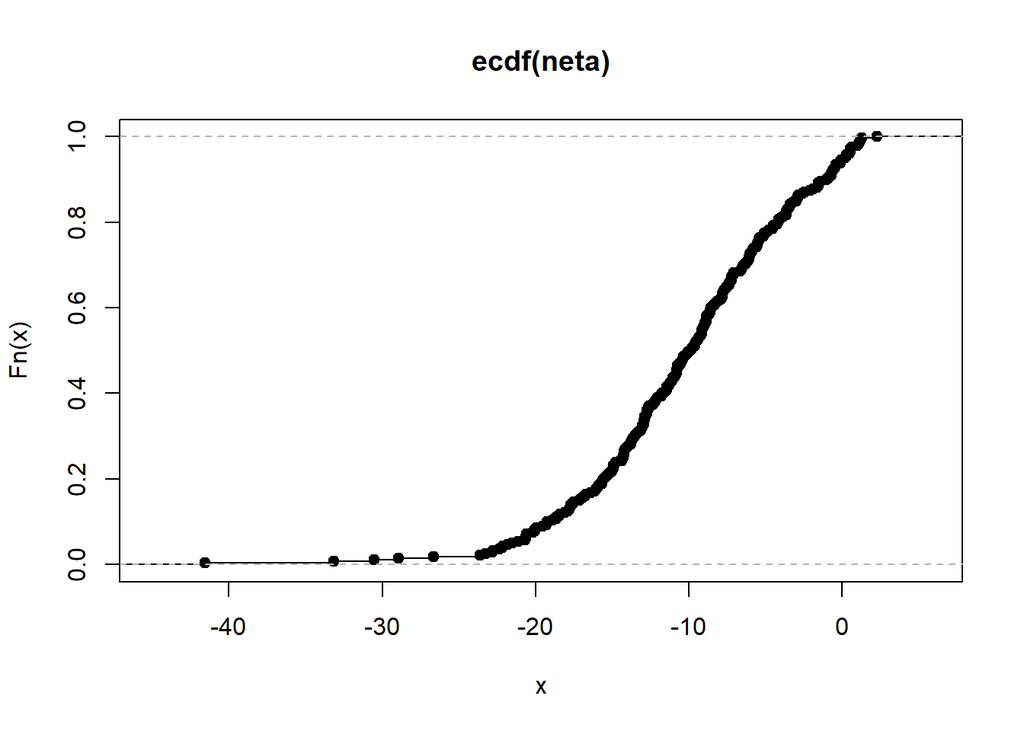

```r
plot(ecdf(neta))
```

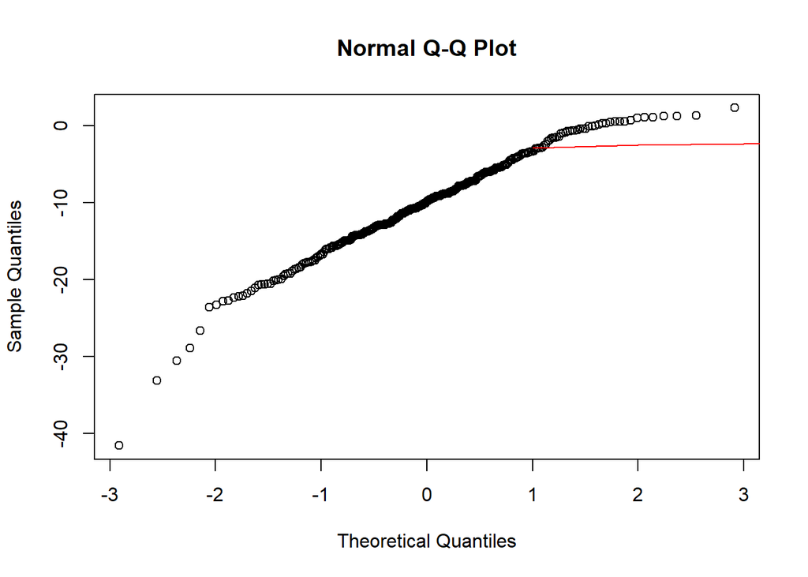

```r
n <- length(neta)
qqnorm(neta)
lines(qnorm((seq(n)-0.5)/n), col="red")
```

```r
n <- length(neta)
qnorm((seq(n)-0.5)/n)
```

```
##   [1] -2.913726318 -2.551881811 -2.368567059 -2.241402728 -2.142629541
##   [6] -2.061181642 -1.991476089 -1.930285856 -1.875570461 -1.825954320
##  [11] -1.780464342 -1.738385800 -1.699177660 -1.662420100 -1.627780538
##  [16] -1.594990833 -1.563831508 -1.534120544 -1.505705244 -1.478456193
##  [21] -1.452262712 -1.427029372 -1.402673290 -1.379121997 -1.356311745
##  [26] -1.334186151 -1.312695086 -1.291793776 -1.271442057 -1.251603755
##  [31] -1.232246166 -1.213339622 -1.194857124 -1.176774021 -1.159067747
##  [36] -1.141717586 -1.124704473 -1.108010820 -1.091620367 -1.075518046
##  [41] -1.059689867 -1.044122815 -1.028804762 -1.013724383 -0.998871089
##  [46] -0.984234960 -0.969806691 -0.955577538 -0.941539277 -0.927684158
##  [51] -0.914004872 -0.900494515 -0.887146559 -0.873954823 -0.860913448
##  [56] -0.848016878 -0.835259832 -0.822637291 -0.810144479 -0.797776846
##  [61] -0.785530053 -0.773399959 -0.761382610 -0.749474224 -0.737671186
##  [66] -0.725970031 -0.714367440 -0.702860231 -0.691445348 -0.680119858
##  [71] -0.668880941 -0.657725886 -0.646652081 -0.635657014 -0.624738261
```

[output cut: 41 more lines]

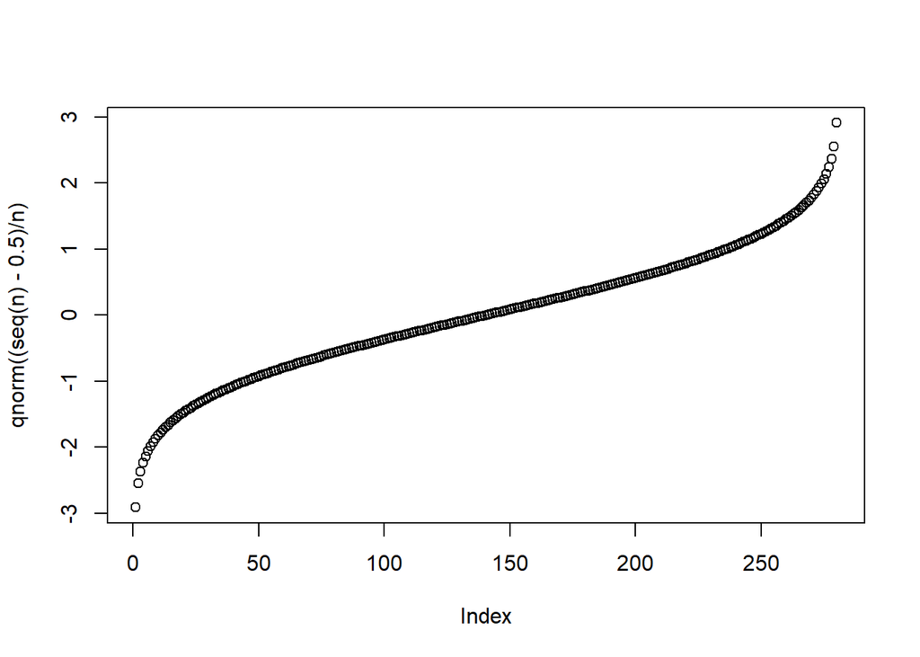

```r
plot(qnorm((seq(n)-0.5)/n))
```

### Пробую на данных Примера из конспекта: (ЭТО МОЖНО НЕ СМОТРЕТЬ)

```r
q1 <- c(68.9,68.1,67.6,69.2,69.2,64.6,67)
q2 <- c(2372,2372,2489,3379,4130,1171,689)
q3 <- c(25.3,28,30,23.5,18,38.4,29.6)
Q <- cbind(q1,q2,q3)
Q
```

```
##        q1   q2   q3
## [1,] 68.9 2372 25.3
## [2,] 68.1 2372 28.0
## [3,] 67.6 2489 30.0
## [4,] 69.2 3379 23.5
## [5,] 69.2 4130 18.0
## [6,] 64.6 1171 38.4
## [7,] 67.0  689 29.6
```

```r
lambdaA <- matrix(0:8,ncol=3,nrow=3)

for(i in (1:3)){
  for(j in (1:3)){
    lambdaA[i,j] <- mean(Q[,i]*Q[,j])-mean(Q[,i])*mean(Q[,j])
  }
}
lambdaA
```

```
##             [,1]        [,2]         [,3]
## [1,]    2.305714    1291.029    -8.318571
## [2,] 1291.028571 1199027.347 -5294.516327
## [3,]   -8.318571   -5294.516    34.399592
```

```r
det(lambdaA)
```

```
## [1] 3882374
```

теперь A[i,j]:

```r
#Делаем проще функцию эту:

AA2 <- matrix(0:8,ncol=3,nrow=3)
lam2 <- matrix(0:8,ncol=3,nrow=3)

for(i in (1:3)){
  for(j in (1:3)){
    if(i%%2!=0){

      if(j%%2!=0){
          lamd <- lambdaA[-i,-j]
          AA2[i,j] <- det(lamd)
      }

      if(j%%2==0){
        lamd <- lambdaA[-i,-j]
        AA2[i,j] <- -det(lamd)
      }

    }

    if(i%%2==0){

       if(j%%2!=0){
          lamd <- lambdaA[-i,-j]
          AA2[i,j] <- -det(lamd)
       }

      if(j%%2==0){
        lamd <- lambdaA[-i,-j]
        AA2[i,j] <- +det(lamd)
      }

    }

  }
}
AA2
```

```
##               [,1]      [,2]        [,3]
## [1,] 13214148.2039 -368.0437 3138822.781
## [2,]     -368.0437   10.1170    1468.129
## [3,]  3138822.7809 1468.1285 1097859.711
```

Считаем beta:

```r
beta2 <- c()
beta2[1] <- mean(Q[,1])
beta2[2] <- -AA2[1,2]/AA2[1,1]
beta2[3] <- -AA2[1,3]/AA2[1,1]
beta2[1] <- beta2[1]-beta2[2]*mean(Q[,2])-beta2[3]*mean(Q[,3])
beta2
```

```
## [1]  7.427634e+01  2.785224e-05 -2.375350e-01
```

Коэффициенты ro:

```r
ro12_3 <- -(AA2[1,2]/(AA2[1,1]*AA2[2,2])^(1/2))
ro12_3
```

```
## [1] 0.03183126
```

```r
ro13_2 <- -(AA2[1,3]/(AA2[1,1]*AA2[3,3])^(1/2))
ro13_2
```

```
## [1] -0.8240884
```

Считаем сигму:

```r
sig1_2 <- lambdaA[1,1]
sig1_2
```

```
## [1] 2.305714
```

```r
AdetA <- det(lambdaA)
sig1_3_2 <- AdetA/AA2[1,1] #Сигма в квадрате
sig1_3_2
```

```
## [1] 0.2938043
```

```r
R2A <- (sig1_2-sig1_3_2)/sig1_2
R2A
```

```
## [1] 0.8725756
```

```r
R2A2 <- R2A^(1/2)
R2A2
```

```
## [1] 0.9341175
```